# Local outlier factors

# 1 Obtention de statistiques reliées aux local outlier factors

J’ai d’abord calculé les *local outlier factors* (LOFs) pour chacun des trajets de chacun des conducteurs. On obtient donc, pour chaque conducteur, une distribution empirique des LOFs. Les LOFs sont obtenus en « silo » pour chaque conducteur. Pour calculer la distribution des LOFs pour le conducteur A, on a donc seulement besoin des données du conducteur A.

Les variables utilisées pour le calcul des LOFs sont:

- duration
- distance
- avg_speed
- max_speed
- cos_time_start
- sin_time_start
- cos_nb_days_since_monday
- sin_nb_days_since_monday.

Dans l’algorithme LOF, il y a un hyperparamètre *k* que l’on doit choisir, et qui correspond au nombre de plus proches voisins à utiliser pour le calcul de la densité locale. J’en ai essayé plusieurs, c’est-à-dire:

- k = 5
- k = 10
- k = 20
- k = 30
- k = 50
- k = 100.

Ensuite, on calcule des statistiques tirées de la distribution empirique des LOFs pour chaque conducteur et pour chaque valeur de *k*. Les statistiques calculées sont:

- mean
- variance
- skewness
- kurtosis
- Quantiles (1%, 5%, 25%, 50%, 75%, 95% et 99%).

On se retrouve donc à créer 11 nouvelles variables pour chaque conducteur. Puisqu’on a calculé les LOFs pour 6 valeurs de *k*, ça fait donc 11 fois 6 = 66 nouvelles variables.

# 2 Impact des 66 nouvelles variables sur la fréquence de réclamation

## Mean

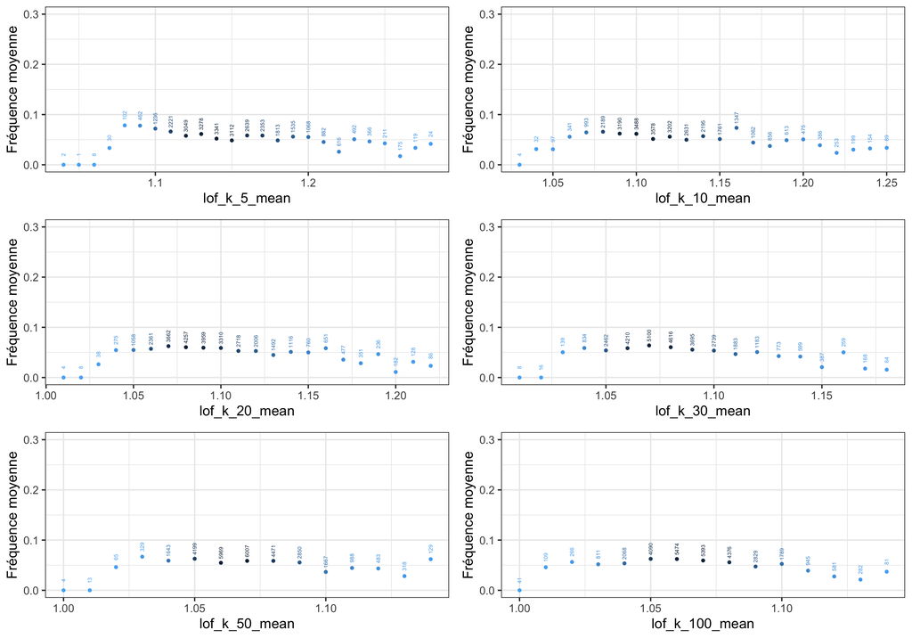

## Variance

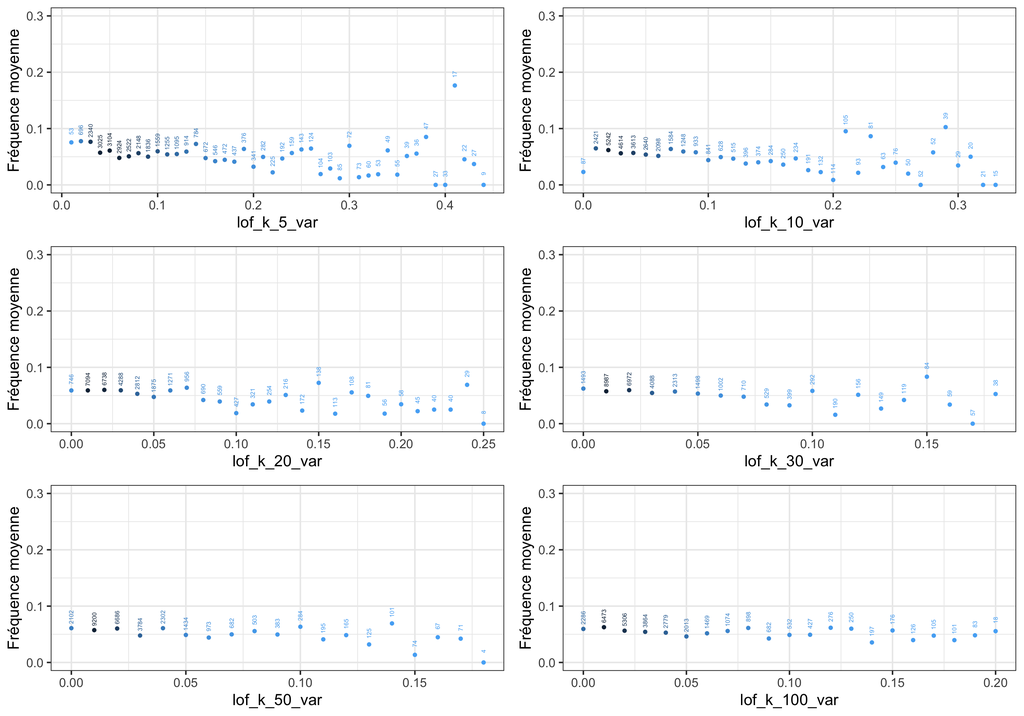

## Skewness

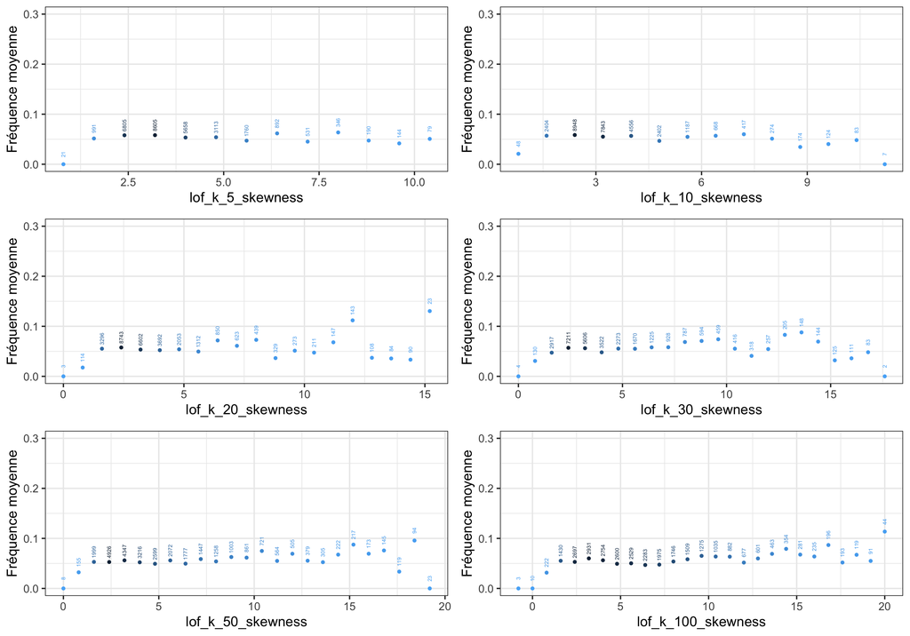

## Kurtosis

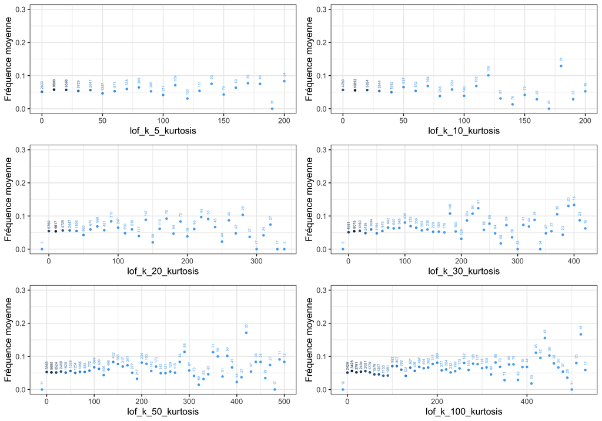

## Quantile 1%

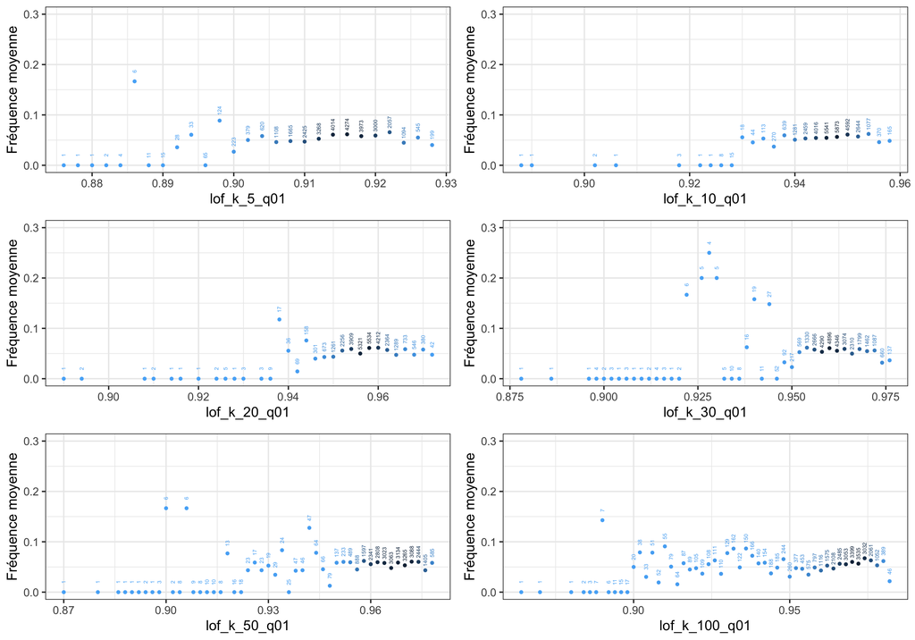

## Quantile 5%

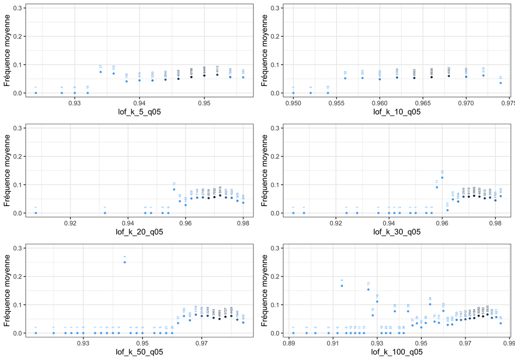

## Quantile 25%

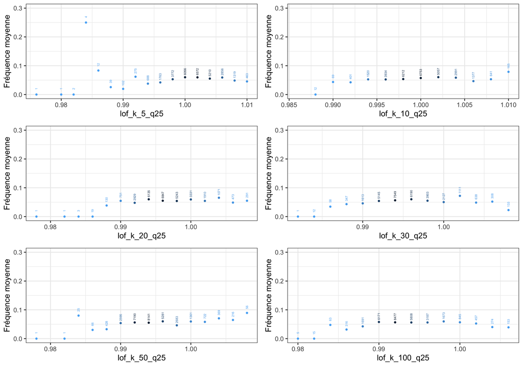

## Quantile 50%

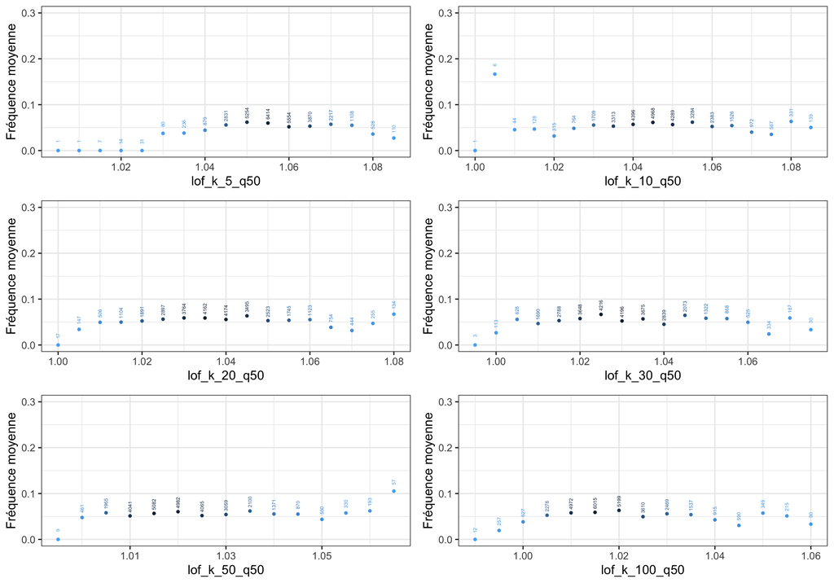

## Quantile 75%

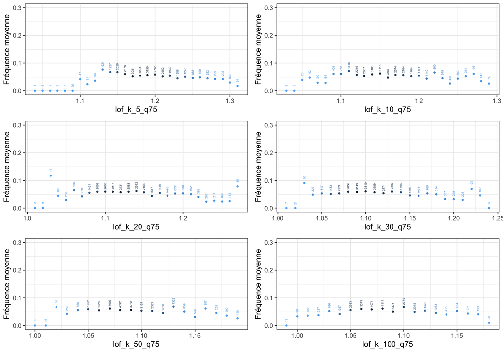

## Quantile 95%

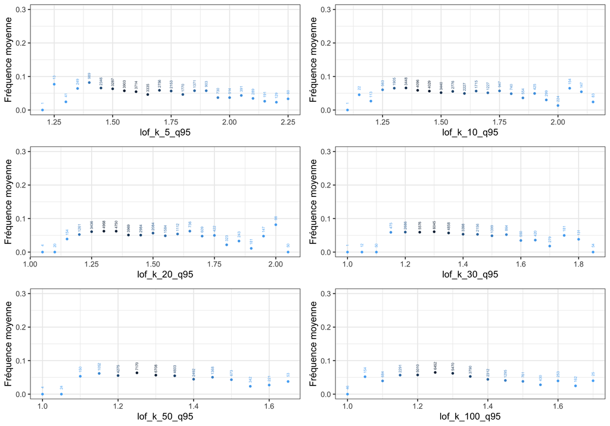

## Quantile 99%

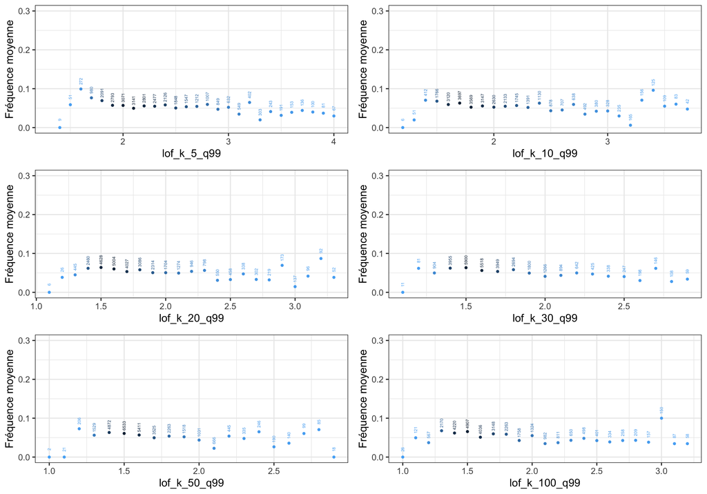

# 3 Distributions des 66 nouvelles variables pour contrats avec versus sans réclamation

## Mean

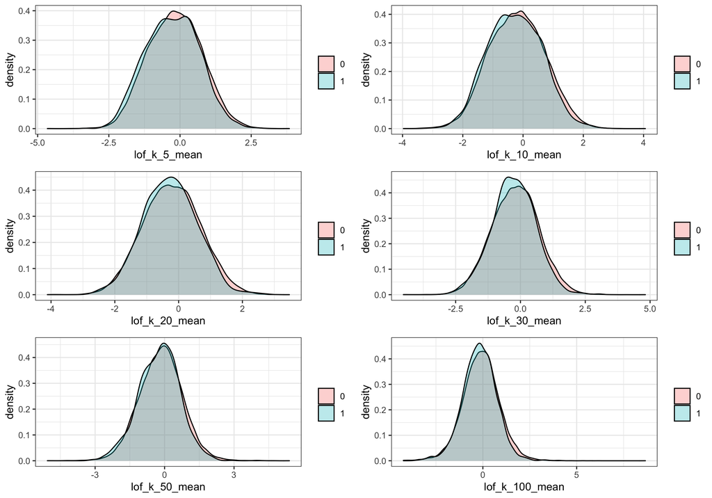

## Variance

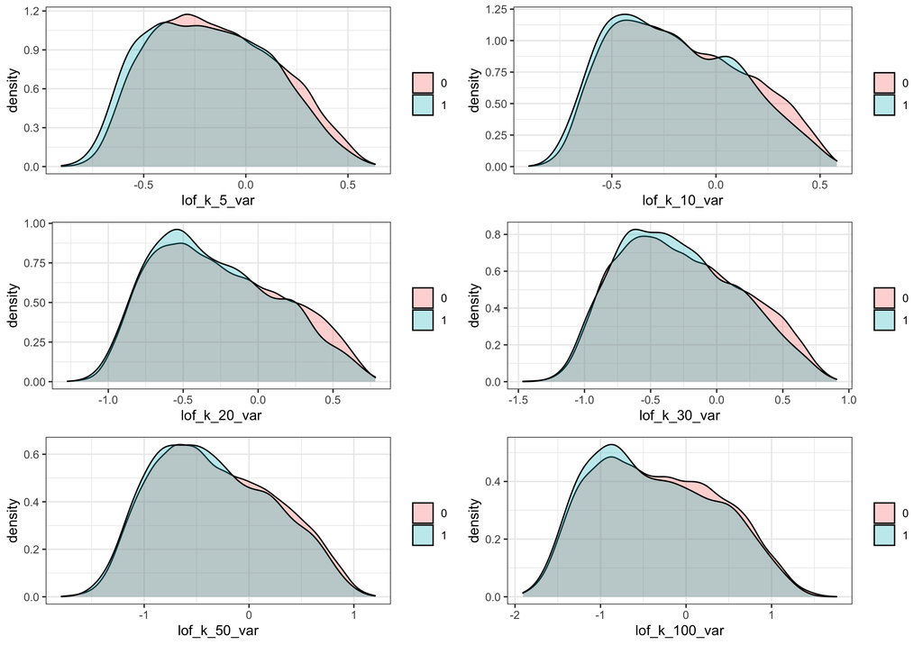

## Skewness

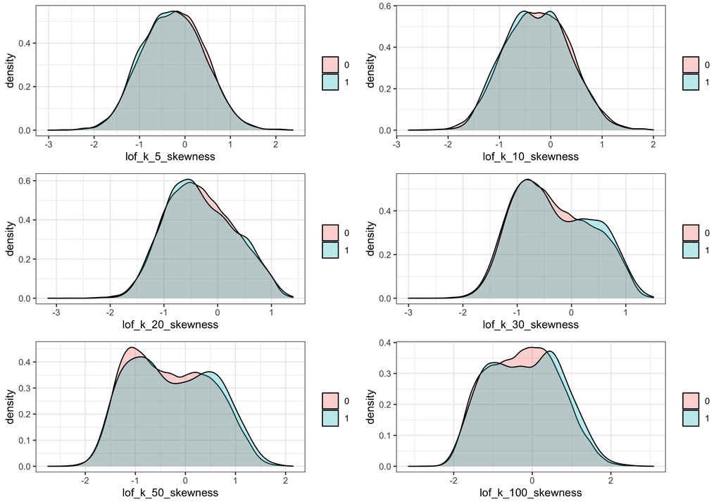

## Kurtosis

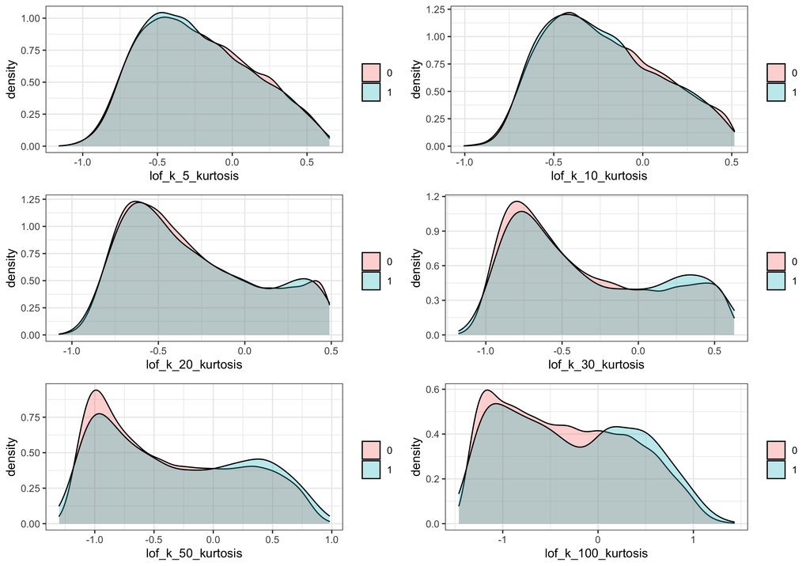

## Quantile 1%

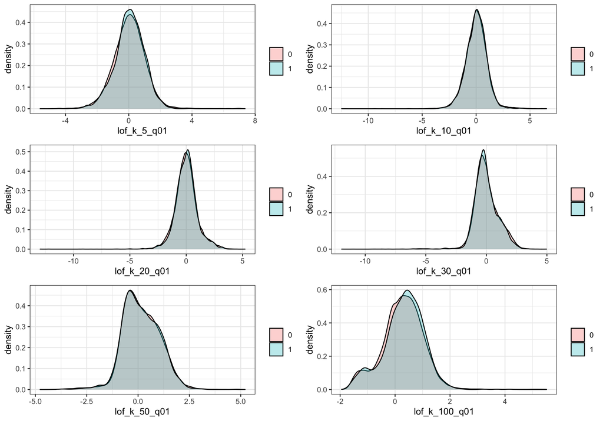

## Quantile 5%

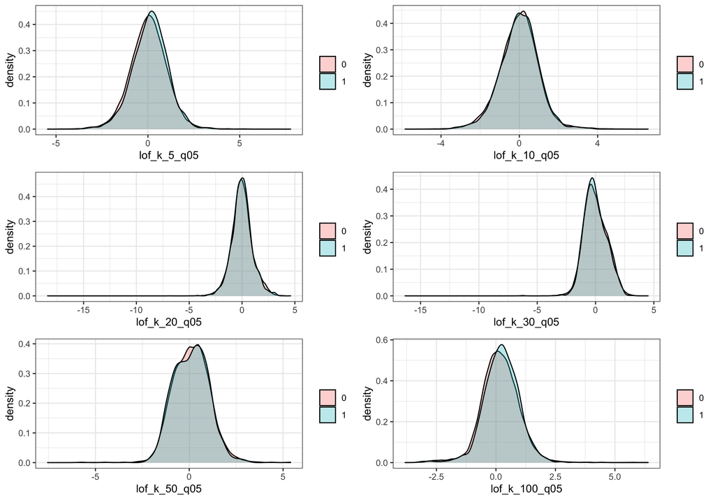

## Quantile 25%

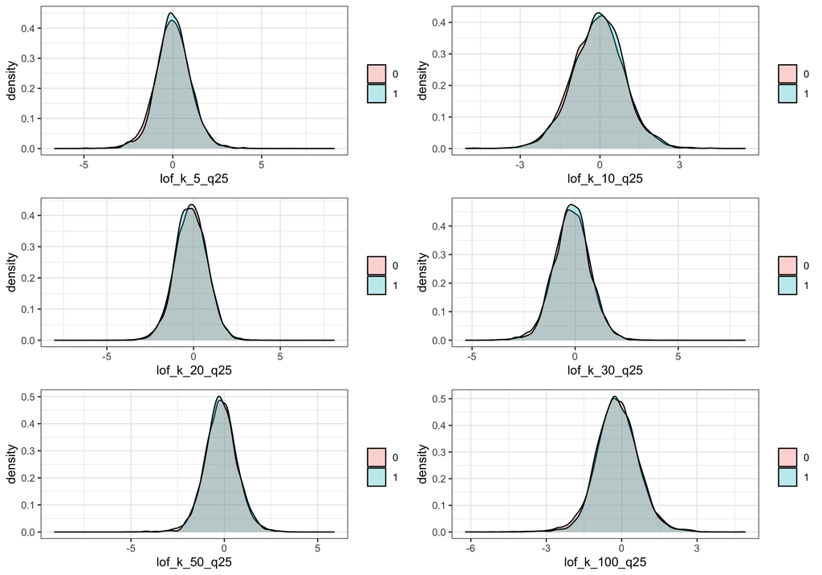

## Quantile 50%

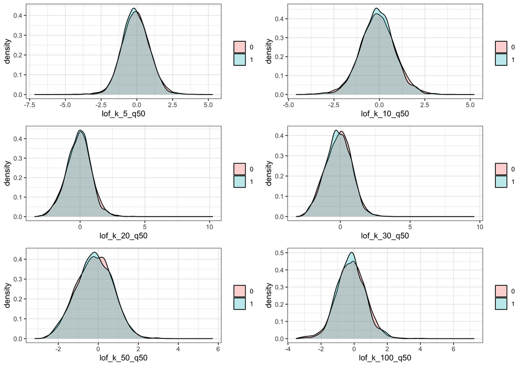

## Quantile 75%

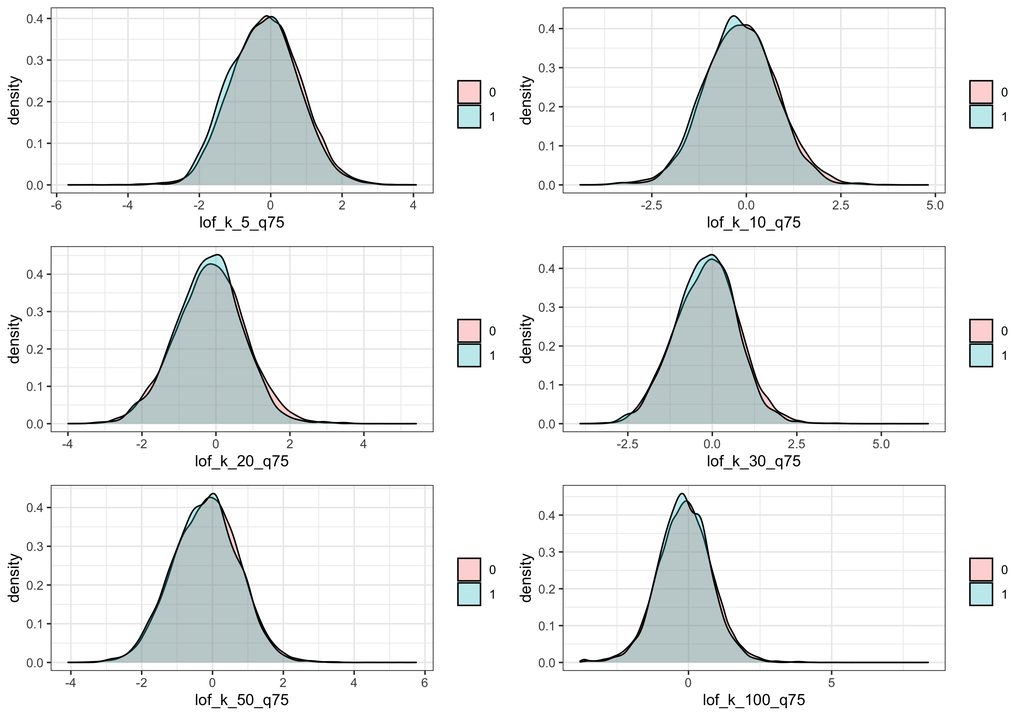

## Quantile 95%

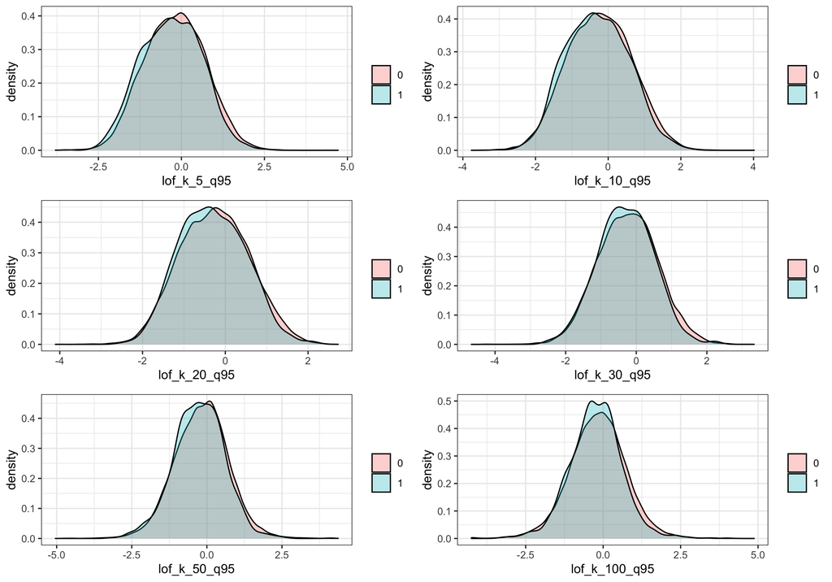

## Quantile 99%

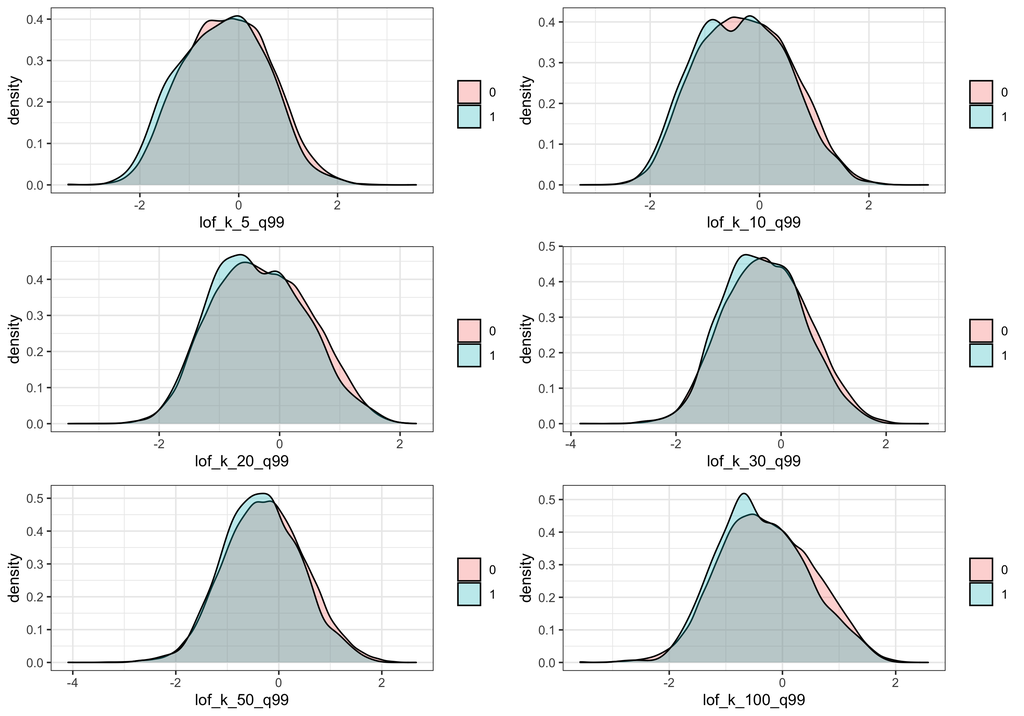

# 4 Régression logistique lasso avec les 66 nouvelles variables

J’ai utilisé les 66 variables dans une régression logistique lasso pour prédire l’indicatrice d’une réclamation ou plus dans le contrat.

J’ai d’abord calibré et entrainé le modèle sur un ensemble d’entrainement pour ensuite le scorer sur un ensemble test. On obtient un AUC d’environ 0.55.

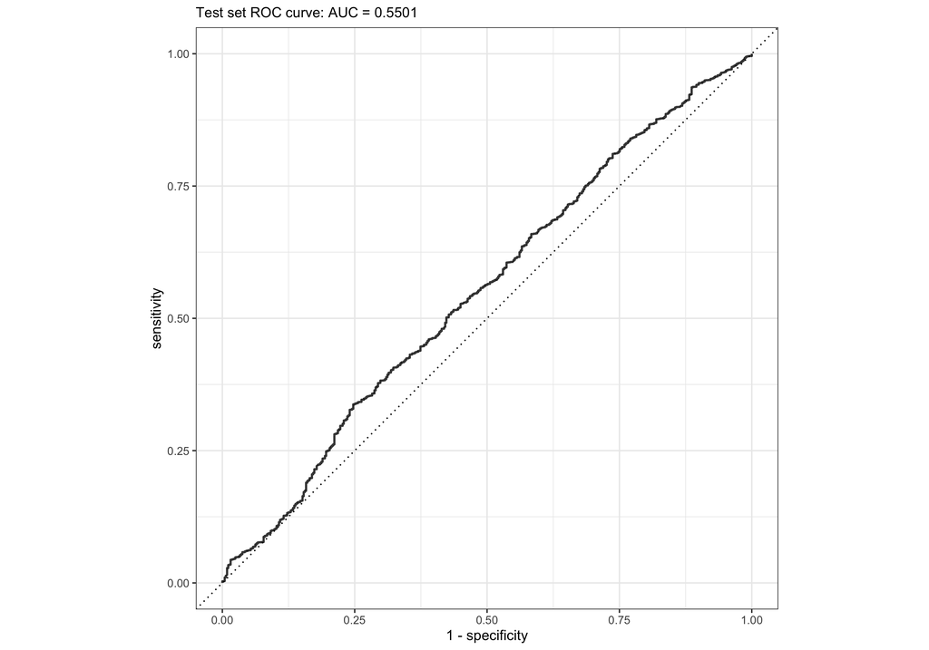

Voici les variables considérées les plus importantes par le modèle:

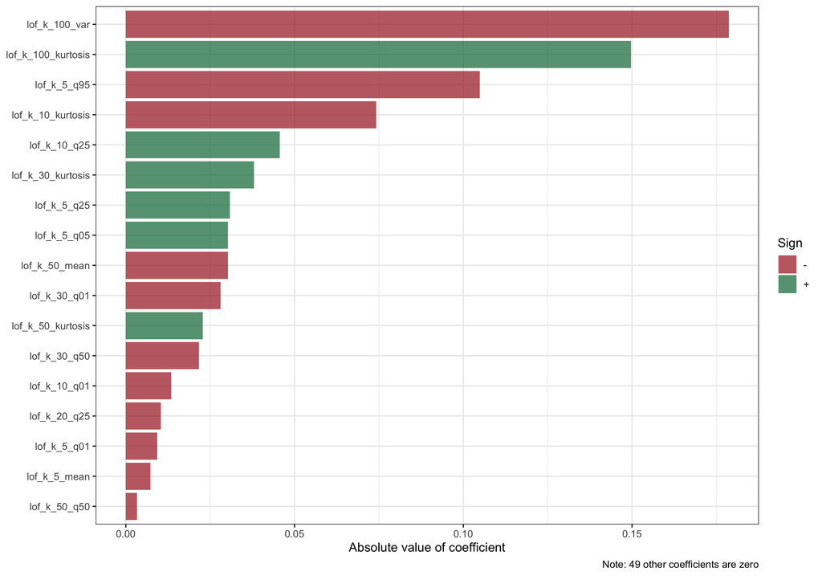

On note que le modèle a mis à zéro 49 coefficients, non visibles sur le graphique.

# 5 Notes

- Les variables tirées des LOFs n’ont pas un pouvoir prédictif incroyable (AUC de 0.55), mais c’est quand même mieux que du « random guessing ».
- On pourrait peut-être donner en entrée les quantiles à un réseau de neurones (disons q01, q02, …, q99) afin qu’il crée lui-même les statistiques optimales.
- Réseau de neurones à plusieurs « têtes »: une tête avec les quantiles des LOFs par conducteur, une autre avec les LOFs « globaux » et une autre avec les caractéristiques ordinaires (genre, région, etc.).
- Il faudrait regarder si l’ajout des 66 variables améliore significativement la performance d’un lasso avec variables classiques.
- Refaire la même analyse avec les LOFs globaux.